# Employer Review Prediction

## Background

[figure not shown]

Source : [Indeed Image](https://rallyrecruitmentmarketing.com/2018/02/18-employer-review-sites-to-put-on-your-radar/)

*Employer Review* adalah sebuah bentuk yang mengacu pada konten yang ditulis oleh seorang *employer* atau karyawan terhadap perusahaannya yang dapat diunggah secara publik ataupun tidak. Setiap organisasi tentunya membutuhkan seseorang untuk menggerakkan organisasi tersebut. Oleh karenanya, setiap *review* yang diberikan terhadap suatu produk, jasa, atau terkait perusahaan tentunya akan berdampak terhadap perusahaan. Setiap *review* baik yang positif ataupun negatif akan memengaruhi keputusan orang atau sekelompok orang yang ingin bergabung, menggunakan jasa, atau membeli produk dari perusahaan tersebut. Dengan mengetahui bagaimana *review* yang diberikan oleh pegawai terhadap perusahaannya, diharapkan pihak perusahaan dapat melakukan evaluasi apabila terdapat banyak *review* negatif atau mempertahankan kinerja dan terus berinovasi apabila terdahap *review* positif.

Data dikumpulkan pada situs [Indeed](https://id.indeed.com/?r=us) yang merupakan salah satu situs lowongan kerja no 1 di dunia dengan lebih dari 250 juta pengunjung unik2 setiap bulannya. Indeed berkomitmen untuk mengutamakan para pencari kerja, memberi mereka akses gratis untuk mencari pekerjaan, membuat CV, dan mencari tahu informasi tentang sebuah perusahaan. Setiap hari, Indeed menghubungkan jutaan orang dengan peluang-peluang baru.

Adapun dataset yang akan digunakan dapat dilihat pada [Employer Review](https://www.kaggle.com/muhammedabdulazeem/employer-review-about-their-organization)

## Business Understanding

1. Mengetahui *review* yang diberikan oleh pegawai terhadap perusahaan.
2. Memprediksi *review* yang diberikan dan mengkategorikannya ke dalam *review* yang bersifat positif, netral, atau negatif.

## Data Understanding

Terdapat 5 buah kolom pada data kita yaitu `ReviewTitle`, `CompleteReview`, `URL`, `Rating`, `ReviewDetails`.

1. `ReviewTitle` : Topik dari *review*.
2. `CompleteReview` : *Review* yang diberikan pegawai perusahaan.
3. `URL` : *Uniform Resource Locator*.
4. `Rating` : Penilaian yang diberikan pegawai perusahaan.
5. `ReviewDetails` : Detail mengenai *review*.

## Import Library

```python
import pandas as pd
import numpy as np
import matplotlib.pyplot as plt
import seaborn as sns
sns.set_theme()

from sklearn.preprocessing import OneHotEncoder
from sklearn.model_selection import train_test_split
from sklearn.metrics import confusion_matrix
from sklearn.metrics import accuracy_score
from imblearn.over_sampling import RandomOverSampler

import tensorflow as tf
import nltk
import re

from tensorflow.keras.preprocessing.text import Tokenizer
from tensorflow.keras.preprocessing.sequence import pad_sequences

from nltk.corpus import stopwords
from nltk.stem.porter import PorterStemmer
nltk.download('stopwords')

import warnings
warnings.filterwarnings('ignore')
```

## Loading Dataset

**Load Data From Github**

```python
# url = "https://raw.githubusercontent.com/ReynaraEzra/Employer-Review/main/data_input/results.json"
# df = pd.read_json(url)
```

**Load Data From Local File**

```python
df = pd.read_json('data_input/results.json')
```

## Checking Dataset

Akan dilihat 5 data teratas, 5 data terbawah, dan 5 data acak pada dataframe `df`.

```python
df.head()
```

|  | ReviewTitle | CompleteReview | URL | Rating | ReviewDetails |
| --- | --- | --- | --- | --- | --- |
| 0 | Productive | Good company, cool workplace, work load little... | https://in.indeed.com/cmp/Reliance-Industries-... | 3 | (Current Employee) - Ghansoli - August 30,... |
| 1 | Stressful | 1. Need to work on boss's whims and fancies 2.... | https://in.indeed.com/cmp/Reliance-Industries-... | 3 | (Former Employee) - - August 26, 2021 |
| 2 | Good Company for Every employee | Good company for every Engineers dream, Full M... | https://in.indeed.com/cmp/Reliance-Industries-... | 5 | (Former Employee) - - August 17, 2021 |
| 3 | Productive | I am just pass out bsc in chemistry Typical da... | https://in.indeed.com/cmp/Reliance-Industries-... | 5 | (Current Employee) - - August 17, 2021 |
| 4 | Non productive | Not so fun at work just blame games Target pe... | https://in.indeed.com/cmp/Reliance-Industries-... | 1 | (Former Employee) - - August 9, 2021 |

```python
df.tail()
```

|  | ReviewTitle | CompleteReview | URL | Rating | ReviewDetails |
| --- | --- | --- | --- | --- | --- |
| 145204 | Definitely very good place to work and can hav... | We get a lot to learn in the company. Very sys... | https://in.indeed.com/cmp/Tata-Consultancy-Ser... | 4 | (Former Employee) - - January 20, 2012 |
| 145205 | IT Services Company; Great scope for improvement. | Lot of scope to learn different technologies u... | https://in.indeed.com/cmp/Tata-Consultancy-Ser... | 4 | (Former Employee) - - January 19, 2012 |
| 145206 | Productive, fun to work, great place to do cer... | An overall positive experience, nice environme... | https://in.indeed.com/cmp/Tata-Consultancy-Ser... | 4 | (Former Employee) - - January 19, 2012 |
| 145207 | Great place to start the career. | Happy that I've started my career from such a ... | https://in.indeed.com/cmp/Tata-Consultancy-Ser... | 3 | (Former Employee) - - January 7, 2012 |
| 145208 | Nice place to work | Got good experience and knowledge about my wor... | https://in.indeed.com/cmp/Tata-Consultancy-Ser... | 5 | (Former Employee) - - December 19, 2011 |

```python
df.sample(5)
```

|  | ReviewTitle | CompleteReview | URL | Rating | ReviewDetails |
| --- | --- | --- | --- | --- | --- |
| 72620 | Moderate experience | Pay scale is fine to manage cost of living. Ho... | https://in.indeed.com/cmp/HSBC/reviews?start=120 | 3 | (Current Employee) - - March 23, 2020 |
| 122387 | good and work with peaceful | Am working with my team full attitude and fun.... | https://in.indeed.com/cmp/Tata-Consultancy-Ser... | 4 | (Current Employee) - - April 15, 2017 |
| 86719 | Work Place Culture | Great Place to Work. You have the liberty to e... | https://in.indeed.com/cmp/Dell-Technologies/re... | 4 | (Former Employee) - - April 10, 2017 |
| 135493 | Depends on project to project | Not a satisfactory experience as a fresher.\r ... | https://in.indeed.com/cmp/Tata-Consultancy-Ser... | 2 | (Current Employee) - - April 29, 2016 |
| 8026 | Good workplace | Good job..free cab..super cafeteria...fun...sl... | https://in.indeed.com/cmp/Teleperformance/revi... | 3 | (Current Employee) - - July 5, 2021 |

## Check Characteristic Data

**Data Shape**

```python
df.shape
```

```
(145209, 5)
```

Terlihat bahwa terdapat 145209 baris pada dataset.

**Data Columns**

```python
df.columns
```

```
Index(['ReviewTitle', 'CompleteReview', 'URL', 'Rating', 'ReviewDetails'], dtype='object')
```

**Data Info**

```python
df.info()
```

```
<class 'pandas.core.frame.DataFrame'>
RangeIndex: 145209 entries, 0 to 145208
Data columns (total 5 columns):
 #   Column          Non-Null Count   Dtype
---  ------          --------------   -----
 0   ReviewTitle     145209 non-null  object
 1   CompleteReview  145209 non-null  object
 2   URL             145209 non-null  object
 3   Rating          145209 non-null  int64
 4   ReviewDetails   145209 non-null  object
dtypes: int64(1), object(4)
memory usage: 5.5+ MB
```

Terdapat 1 kolom yang bertipe integer dan 4 kolom yang bertipe object.

**Descriptive Statistic**

```python
df.describe()
```

|  | Rating |
| --- | --- |
| count | 145209.000000 |
| mean | 4.053661 |
| std | 0.925805 |
| min | 1.000000 |
| 25% | 4.000000 |
| 50% | 4.000000 |
| 75% | 5.000000 |
| max | 5.000000 |

Berdasarkan statistika deskriptif di atas, terlihat untuk rataan *Rating* yang diberikan oleh pegawai terhadap organisasi atau perusahaannya adalah 4,053.

**Check Missing Value**

Untuk melihat apakah terdapat data yang kosong, kita dapat menggunakan `.isnull()` dan `.sum()`.

```python
df.isnull().sum()
```

```
ReviewTitle       0
CompleteReview    0
URL               0
Rating            0
ReviewDetails     0
dtype: int64
```

Tidak ada data yang kosong.

**Check and Drop Duplicate Data**

Untuk membuang data duplikat, dapat digunakan `.drop_duplicates().`.

```python
df = df.drop_duplicates(keep='first')
df.reset_index(drop=True, inplace=True)
```

```python
df.shape
```

```
(145191, 5)
```

Jumlah data setelah dibuang data duplikat adalah 145191 baris.

## Feature Extraction

Dikarenakan jumlah kolom atau *feature* yang kita miliki masih sedikit, akan sulit untuk melakukan tahapan eksplorasi pada data kita. Oleh karena itu, akan dibentuk *feature* atau kolom baru berdasarkan kolom yang telah ada.

```python
df.head(3)
```

|  | ReviewTitle | CompleteReview | URL | Rating | ReviewDetails |
| --- | --- | --- | --- | --- | --- |
| 0 | Productive | Good company, cool workplace, work load little... | https://in.indeed.com/cmp/Reliance-Industries-... | 3 | (Current Employee) - Ghansoli - August 30,... |
| 1 | Stressful | 1. Need to work on boss's whims and fancies 2.... | https://in.indeed.com/cmp/Reliance-Industries-... | 3 | (Former Employee) - - August 26, 2021 |
| 2 | Good Company for Every employee | Good company for every Engineers dream, Full M... | https://in.indeed.com/cmp/Reliance-Industries-... | 5 | (Former Employee) - - August 17, 2021 |

**Make Company Name Columns**

Pada kolom `URL`, dapat diperoleh informasi terkait nama perusahaan yang diberikan *review* oleh pegawainya. Untuk dapat mengambil nama, dapat dilakukan proses *slicing* data menggunakan acessor `.str` yang dapat digunakan untuk data bertipe string/object dan method `.split()` dengan parameter `/`. Kolom yang memuat nama perusahaan tersebut akan kita simpan ke dalam `Company Name`.

```python
df['Company Name'] = df['URL'].str.split('/')
df['Company Name'] = df['Company Name'].str[4]
```

```python
df['Company Name'].head()
```

```
0    Reliance-Industries-Ltd
1    Reliance-Industries-Ltd
2    Reliance-Industries-Ltd
3    Reliance-Industries-Ltd
4    Reliance-Industries-Ltd
Name: Company Name, dtype: object
```

```python
df['Company Name'].unique()
```

```
array(['Reliance-Industries-Ltd', 'Mphasis', 'Kpmg', 'Yes-Bank',
       'Sutherland', 'Marriott-International,-Inc.', 'DHL', 'Jio',
       'Vodafoneziggo', 'HP', 'Maersk', 'Ride.swiggy', 'Jll', 'Alstom',
       'UnitedHealth-Group', 'Tata-Consultancy-Services-(tcs)',
       'Capgemini', 'Teleperformance', 'Cognizant-Technology-Solutions',
       'Mahindra-&-Mahindra-Ltd', 'L&T-Technology-Services-Ltd.',
       'Bharti-Airtel-Limited', 'Indeed', 'Hyatt',
       'Icici-Prudential-Life-Insurance', 'Accenture', 'Honeywell',
       'Standard-Chartered-Bank', 'Nokia', 'Apollo-Hospitals',
       'Tata-Aia-Life', 'Hdfc-Bank', 'Bosch', 'Deloitte', 'Ey',
       'Microsoft', 'Barclays', 'JPMorgan-Chase', 'Muthoot-Finance',
       'Wns-Global-Services', 'Kotak-Mahindra-Bank', 'Infosys', 'Oracle',
       "Byju's", 'Deutsche-Bank', 'Hinduja-Global-Solutions', 'Ericsson',
       'Axis-Bank', 'IBM', 'Concentrix', 'Wells-Fargo', 'Google',
       'Dell-Technologies', 'Facebook', 'Amazon.com', 'Flipkart.com',
       'American-Express', 'Citi', 'HSBC'], dtype=object)
```

Terlihat nama perusahaan yang ada pada dataset kita setelah dilakukan proses *slicing*.

```python
df.head()
```

|  | ReviewTitle | CompleteReview | URL | Rating | ReviewDetails | Company Name |
| --- | --- | --- | --- | --- | --- | --- |
| 0 | Productive | Good company, cool workplace, work load little... | https://in.indeed.com/cmp/Reliance-Industries-... | 3 | (Current Employee) - Ghansoli - August 30,... | Reliance-Industries-Ltd |
| 1 | Stressful | 1. Need to work on boss's whims and fancies 2.... | https://in.indeed.com/cmp/Reliance-Industries-... | 3 | (Former Employee) - - August 26, 2021 | Reliance-Industries-Ltd |
| 2 | Good Company for Every employee | Good company for every Engineers dream, Full M... | https://in.indeed.com/cmp/Reliance-Industries-... | 5 | (Former Employee) - - August 17, 2021 | Reliance-Industries-Ltd |
| 3 | Productive | I am just pass out bsc in chemistry Typical da... | https://in.indeed.com/cmp/Reliance-Industries-... | 5 | (Current Employee) - - August 17, 2021 | Reliance-Industries-Ltd |
| 4 | Non productive | Not so fun at work just blame games Target pe... | https://in.indeed.com/cmp/Reliance-Industries-... | 1 | (Former Employee) - - August 9, 2021 | Reliance-Industries-Ltd |

**Make Date Columns**

Selain membuat kolom `Company Name`, akan dibuat juga kolom `Date` yang memuat tanggal *review* diberikan. Untuk mendapatkan tanggal, dapat dilakukan proses *slicing* pada kolom `ReviewDetails` menggunakan acessor `.str` dan method `.split()`.

```python
df['Date'] = df['ReviewDetails'].str.split('-', expand=True)[2]
```

```python
df.head()
```

|  | ReviewTitle | CompleteReview | URL | Rating | ReviewDetails | Company Name | Date |
| --- | --- | --- | --- | --- | --- | --- | --- |
| 0 | Productive | Good company, cool workplace, work load little... | https://in.indeed.com/cmp/Reliance-Industries-... | 3 | (Current Employee) - Ghansoli - August 30,... | Reliance-Industries-Ltd | August 30, 2021 |
| 1 | Stressful | 1. Need to work on boss's whims and fancies 2.... | https://in.indeed.com/cmp/Reliance-Industries-... | 3 | (Former Employee) - - August 26, 2021 | Reliance-Industries-Ltd | August 26, 2021 |
| 2 | Good Company for Every employee | Good company for every Engineers dream, Full M... | https://in.indeed.com/cmp/Reliance-Industries-... | 5 | (Former Employee) - - August 17, 2021 | Reliance-Industries-Ltd | August 17, 2021 |
| 3 | Productive | I am just pass out bsc in chemistry Typical da... | https://in.indeed.com/cmp/Reliance-Industries-... | 5 | (Current Employee) - - August 17, 2021 | Reliance-Industries-Ltd | August 17, 2021 |
| 4 | Non productive | Not so fun at work just blame games Target pe... | https://in.indeed.com/cmp/Reliance-Industries-... | 1 | (Former Employee) - - August 9, 2021 | Reliance-Industries-Ltd | August 9, 2021 |

**Make Year, Month, Day Columns**

Dilakukan proses pembentukan kolom `Year`, `Month`, dan `Day` yang memuat tahun, bulan, dan tanggal *review* diberikan.

```python
df['Year'] = df['Date'].str.split(',', expand=True)[1]
```

```python
df['Month'] = df['Date'].str.split(' ', expand=True)[2]
```

```python
df['Day'] = df['Date'].str.split(' ', expand=True)[3]
df['Day'] = df['Day'].str.replace(',','')
```

**Check Columns**

Kolom `Year`

```python
df['Year'].unique()
```

```
array([' 2021', ' 2020', ' 2019', ' 2018', ' 2017', ' 2016', None,
       ' 2015', ' 2014', ' 2013', ' 2012', ' 2011',
       ' GWAL PAHARI GURGAON  ', ' airoli  ', ' Malad west  ',
       ' Sp Infocity & Quadra ', ' New Delhi', ' Tamil nadu  ',
       'Gurgaon  '], dtype=object)
```

Ketika kita mengecek kolom `Year`, terlihat bahwa terdapat beberapa nilai yang tidak sesuai. Oleh karenanya itu kita akan membuang beberapa nilai yang bukanlah tahun dimana *review* diberikan.

```python
df['Year'] = df['Year'].str.replace(' ','')
```

```python
df['Year'].unique()
```

```
array(['2021', '2020', '2019', '2018', '2017', '2016', None, '2015',
       '2014', '2013', '2012', '2011', 'GWALPAHARIGURGAON', 'airoli',
       'Maladwest', 'SpInfocity&Quadra', 'NewDelhi', 'Tamilnadu',
       'Gurgaon'], dtype=object)
```

```python
df['Year'].value_counts(sort=False)
```

```
2021                  2967
2020                 12674
2019                 16985
2018                 15782
2017                 37335
2016                 15295
2015                 13664
2014                 15016
2013                 11140
2012                  4153
2011                    38
GWALPAHARIGURGAON        1
airoli                   1
Maladwest                1
SpInfocity&Quadra        1
NewDelhi                 1
Tamilnadu                1
Gurgaon                  1
Name: Year, dtype: int64
```

```python
df['Year'].isnull().sum()
```

```
135
```

```python
valid_year = ['2011', '2012', '2013', '2014', '2014', '2015',
               '2016', '2017', '2018', '2019', '2020', '2021']
df['Year'] = df['Year'].apply(lambda x:x if x in valid_year else np.nan)
```

```python
df['Year'].value_counts()
```

```
2017    37335
2019    16985
2018    15782
2016    15295
2014    15016
2015    13664
2020    12674
2013    11140
2012     4153
2021     2967
2011       38
Name: Year, dtype: int64
```

Nilai pada kolom `Year` sudah sesuai.

```python
df['Year'].isnull().sum()
```

```
142
```

Kolom `Month`

```python
df['Month'].unique()
```

```
array(['August', 'July', 'September', 'May', 'June', 'April', 'March',
       'February', 'January', 'December', 'November', 'October', '',
       'Africa', 'bagh', 'Consultant', 'Road', '9', '.CLUSTER', '(west)',
       'West', 'PAHARI', 'mumbai', None, 'west', 'Ramannagar', 'West.',
       'Raman', 'park', 'Technohub', 'Solutions', 'Office', 'Estate',
       'Infocity', 'Nagar', 'Delhi,', 'Tamil', 'parel', ')', 'Locatino',
       'complex'], dtype=object)
```

Pada kolom `Month` juga memuat beberapa nilai yang tidak merupakan nama bulan, sama seperti sebelumnya, akan dibuang beberapa nilai.

```python
df['Month'].value_counts()
```

```
March         15438
January       12626
June          12573
July          12214
September     12090
February      12008
May           11848
April         11667
August        11635
November      11397
October       10945
December      10608
                114
Infocity          1
Technohub         1
Solutions         1
Office            1
Estate            1
Locatino          1
Nagar             1
Delhi,            1
Tamil             1
parel             1
)                 1
Raman             1
park              1
West              1
West.             1
Ramannagar        1
west              1
mumbai            1
PAHARI            1
(west)            1
.CLUSTER          1
9                 1
Road              1
Consultant        1
bagh              1
Africa            1
complex           1
Name: Month, dtype: int64
```

```python
df['Month'].isnull().sum()
```

```
1
```

```python
valid_month = ['January', 'February', 'March', 'April', 'May', 'June',
               'July', 'August', 'September', 'October', 'November', 'December']
df['Month'] = df['Month'].apply(lambda x:x if x in valid_month else np.nan)
```

```python
df['Month'].value_counts()
```

```
March        15438
January      12626
June         12573
July         12214
September    12090
February     12008
May          11848
April        11667
August       11635
November     11397
October      10945
December     10608
Name: Month, dtype: int64
```

Nilai pada kolom `Month` sudah sesuai.

```python
df['Month'].isnull().sum()
```

```
142
```

Kolom `Day`

```python
df['Day'].unique()
```

```
array(['30', '26', '17', '9', '22', '18', '7', '8', '5', '3', '15', '6',
       '20', '2', '16', '10', '31', '23', '11', '28', '24', '21', '19',
       '13', '1', '4', '25', '12', '27', '29', '14', None, '',
       'chandigarh', '&', 'GURGAON', 'Nagar', 'malad', 'India', 'nadu'],
      dtype=object)
```

Pada kolom `Day` juga terdapat nilai yang bukan merupakan tanggal. Dilakukan proses serupa seperti pada kolom `Year` dan `Month`.

```python
df['Day'].value_counts()
```

```
5             5159
2             4992
4             4969
21            4929
9             4920
3             4910
8             4910
7             4881
17            4864
12            4842
6             4829
22            4828
20            4825
23            4824
18            4823
```

[output cut: 25 more lines]

```python
valid_day = ['1', '2', '3', '4', '5', '6', '7', '8', '9', '10', '11',
             '12', '13', '14', '15', '16', '17', '18', '19', '20', '21',
             '22', '23', '24', '25', '26', '27', '28', '29', '30', '31']
df['Day'] = df['Day'].apply(lambda x:x if x in valid_day else np.nan)
```

```python
df['Day'].isnull().sum()
```

```
142
```

**Check Missing Value**

```python
df.isnull().sum()
```

```
ReviewTitle         0
CompleteReview      0
URL                 0
Rating              0
ReviewDetails       0
Company Name        0
Date                0
Year              142
Month             142
Day               142
dtype: int64
```

Terlihat bahwa terdapat *missing value* pada kolom `Year`, `Month`, dan `Day`.

```python
df.shape
```

```
(145191, 10)
```

```python
df = df.dropna()
```

Dilakukan proses *drop* pada baris yang memuat *missing value* menggunakan method `.dropna()`.

```python
df.shape
```

```
(145049, 10)
```

Jumlah data setelah dilakukan proses *drop* menjadi 145049 baris.

```python
df.isnull().sum()
```

```
ReviewTitle       0
CompleteReview    0
URL               0
Rating            0
ReviewDetails     0
Company Name      0
Date              0
Year              0
Month             0
Day               0
dtype: int64
```

**Create Date Columns**

Akan diubah tipe data pada kolom `Date` menjadi *datetime* untuk memudahkan proses pada tahap eksplorasi data.

```python
df['Date'] = df['Year']+df['Month']+df['Day']
df['Date'] = pd.to_datetime(df['Date'], format='%Y%B%d')
```

```python
df.head()
```

|  | ReviewTitle | CompleteReview | URL | Rating | ReviewDetails | Company Name | Date | Year | Month | Day |
| --- | --- | --- | --- | --- | --- | --- | --- | --- | --- | --- |
| 0 | Productive | Good company, cool workplace, work load little... | https://in.indeed.com/cmp/Reliance-Industries-... | 3 | (Current Employee) - Ghansoli - August 30,... | Reliance-Industries-Ltd | 2021-08-30 | 2021 | August | 30 |
| 1 | Stressful | 1. Need to work on boss's whims and fancies 2.... | https://in.indeed.com/cmp/Reliance-Industries-... | 3 | (Former Employee) - - August 26, 2021 | Reliance-Industries-Ltd | 2021-08-26 | 2021 | August | 26 |
| 2 | Good Company for Every employee | Good company for every Engineers dream, Full M... | https://in.indeed.com/cmp/Reliance-Industries-... | 5 | (Former Employee) - - August 17, 2021 | Reliance-Industries-Ltd | 2021-08-17 | 2021 | August | 17 |
| 3 | Productive | I am just pass out bsc in chemistry Typical da... | https://in.indeed.com/cmp/Reliance-Industries-... | 5 | (Current Employee) - - August 17, 2021 | Reliance-Industries-Ltd | 2021-08-17 | 2021 | August | 17 |
| 4 | Non productive | Not so fun at work just blame games Target pe... | https://in.indeed.com/cmp/Reliance-Industries-... | 1 | (Former Employee) - - August 9, 2021 | Reliance-Industries-Ltd | 2021-08-09 | 2021 | August | 9 |

**Create Employee Status Columns**

Dibentuk kolom baru yaitu `Employee Status` yang memuat status pegawai terhadap perusahaannya saat ia memberikan *review*.

```python
df['Employee Status'] = df['ReviewDetails'].str.split('-', expand=True)[0]
```

```python
df['Employee Status'].unique()
```

```
array(['(Current Employee)  ', '(Former Employee)  ',
       'Training   (Former Employee)  ', 'Officer   (Former Employee)  ',
       'Leader   (Current Employee)  ',
       'health care   (Current Employee)  ',
       'Good team worker   (Former Employee)  ',
       'Officer   (Current Employee)  ',
       'Sr.G.M.Engineering and projects .   (Former Employee)  ',
       'Hospitality   (Former Employee)  ',
       'Employee   (Current Employee)  ',
       'Employee   (Former Employee)  ', 'Worker   (Former Employee)  ',
       'SBI PR outbound    (Current Employee)  ',
       'PR in SBI outbound    (Current Employee)  ',
       'SBI PR    (Former Employee)  ', 'Senior   (Former Employee)  ',
       'Sbi inbound    (Current Employee)  ',
       'KOTAK CARD    (Current Employee)  ',
       'Marketing   (Current Employee)  ', 'Yes   (Current Employee)  ',
       'Kotak cardit card    (Current Employee)  ',
       'Kotak cards    (Current Employee)  ',
       'OFFICER   (Current Employee)  ',
       'Marketing   (Former Employee)  ',
       'Ocwen, loan verification process    (Current Employee)  ',
       'Accounts   (Former Employee)  ', 'officer   (Former Employee)  ',
       'Ocwen process    (Current Employee)  ',
       'officer   (Current Employee)  ',
       'Communications   (Current Employee)  ',
       'N/A   (Former Employee)  ', 'SA   (Current Employee)  ',
       'Store   (Former Employee)  ', 'Generalist   (Former Employee)  ',
       'part time job   (Current Employee)  ',
       'Handle the Corportae clients for Sim activations.   (Former Employee)  ',
       'training   (Former Employee)  ', 'TRAINING   (Former Employee)  ',
       'Inbound process    (Current Employee)  ',
       'excellent    (Current Employee)  ',
       'health care   (Former Employee)  ',
       'Student   (Former Employee)  ', 'yes   (Current Employee)  ',
       'hospitality   (Former Employee)  ',
       'Good team worker   (Current Employee)  ',
       'New Joining    (Current Employee)  ',
       'Customer   (Current Employee)  ',
       'Applicant   (Current Employee)  ',
       'Scenior Transaction Processing Officer.   (Former Employee)  ',
```

[output cut: 102 more lines]

```
       'Full Time Employee   (Former Employee)  ',
       'Juniour SAP Support.   (Current Employee)  ',
       'Worked as an CSE in IBM concentrix for One Year.   (Former Employee)  ',
       'Regular Employee   (Current Employee)  ',
       'any jobs   (Former Employee)  ',
       'finance department   (Former Employee)  ',
       '3+ years of experience in Java Technologies.   (Current Employee)  ',
       'SSE , testing    (Current Employee)  ',
       'System Egg.   (Former Employee)  ',
       'Senior Telecom Engr.   (Current Employee)  ',
       'WORKER   (Current Employee)  ',
       'Various Positions   (Current Employee)  ',
       'Airline Fares and GDS.   (Current Employee)  ',
       'QUALITY   (Former Employee)  ',
       'PROGRAMER .........   (Former Employee)  '], dtype=object)
```

```python
df['Employee Status']
```

```
0         (Current Employee)
1          (Former Employee)
2          (Former Employee)
3         (Current Employee)
4          (Former Employee)
                  ...
145186     (Former Employee)
145187     (Former Employee)
145188     (Former Employee)
145189     (Former Employee)
145190     (Former Employee)
Name: Employee Status, Length: 145049, dtype: object
```

Dikarenakan pada kolom `Employee Status` memuat banyak nilai data yang beragam, akan dilakukan proses simplifikasi kategori ke dalam dua buah kategori yaitu *Former Employee* dan *Current Employee*.

```python
def get_status_employee(row_value):
    return 'Former Employee' if 'Former Employee' in row_value else 'Current Employee'
```

```python
df['Employee Status'] = df.apply(lambda x: get_status_employee(x['Employee Status']), axis=1)
```

```python
df.head()
```

|  | ReviewTitle | CompleteReview | URL | Rating | ReviewDetails | Company Name | Date | Year | Month | Day | Employee Status |
| --- | --- | --- | --- | --- | --- | --- | --- | --- | --- | --- | --- |
| 0 | Productive | Good company, cool workplace, work load little... | https://in.indeed.com/cmp/Reliance-Industries-... | 3 | (Current Employee) - Ghansoli - August 30,... | Reliance-Industries-Ltd | 2021-08-30 | 2021 | August | 30 | Current Employee |
| 1 | Stressful | 1. Need to work on boss's whims and fancies 2.... | https://in.indeed.com/cmp/Reliance-Industries-... | 3 | (Former Employee) - - August 26, 2021 | Reliance-Industries-Ltd | 2021-08-26 | 2021 | August | 26 | Former Employee |
| 2 | Good Company for Every employee | Good company for every Engineers dream, Full M... | https://in.indeed.com/cmp/Reliance-Industries-... | 5 | (Former Employee) - - August 17, 2021 | Reliance-Industries-Ltd | 2021-08-17 | 2021 | August | 17 | Former Employee |
| 3 | Productive | I am just pass out bsc in chemistry Typical da... | https://in.indeed.com/cmp/Reliance-Industries-... | 5 | (Current Employee) - - August 17, 2021 | Reliance-Industries-Ltd | 2021-08-17 | 2021 | August | 17 | Current Employee |
| 4 | Non productive | Not so fun at work just blame games Target pe... | https://in.indeed.com/cmp/Reliance-Industries-... | 1 | (Former Employee) - - August 9, 2021 | Reliance-Industries-Ltd | 2021-08-09 | 2021 | August | 9 | Former Employee |

## Exploratory Data Analysis (EDA)

Definisikan beberapa fungsi yang dapat memudahkan dalam membuat plot pada saat mengeksplor data.

```python
def make_count_plot(data, xlabel, size_x, size_y):
    plt.figure(figsize=(size_x, size_y))
    sns.countplot(data)
    plt.xlabel(xlabel, fontsize=12)
    plt.ylabel('Frequency', fontsize=12)
    plt.title(f'Number of Reviews Based on {xlabel}', fontsize=15)
    plt.show()
```

```python
def make_count_plot_hue(data, xlabel, size_x, size_y, hue):
    plt.figure(figsize=(size_x, size_y))
    sns.countplot(data, hue=hue)
    plt.xlabel(xlabel, fontsize=12)
    plt.ylabel('Frequency', fontsize=12)
    plt.title(f'Number of Reviews Based on {xlabel}', fontsize=15)
    plt.show()
```

```python
def make_count_plot_order(data, xlabel, size_x, size_y, order):
    plt.figure(figsize=(size_x, size_y))
    sns.countplot(data, order=order)
    plt.xlabel(xlabel, fontsize=12)
    plt.ylabel('Frequency', fontsize=12)
    plt.title(f'Number of Reviews Based on {xlabel}', fontsize=15)
    plt.show()
```

**Status Employee**

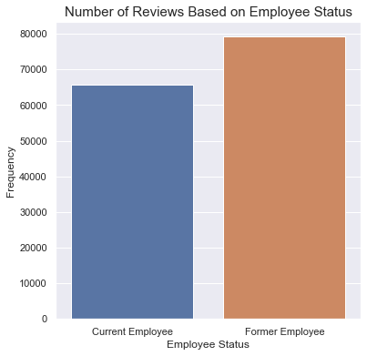

```python
make_count_plot(df['Employee Status'], 'Employee Status', 6, 6)
```

```python
print('Jumlah Review dari Current Employee : {}'.format(sum(df['Employee Status']=='Current Employee')))
print('Jumlah Review dari Former Employee : {}'.format(sum(df['Employee Status']=='Former Employee')))
print('')
print('Persentase Review dari Current Employee : {:.2f}%'.format(sum(df['Employee Status']=='Current Employee')/df.shape[0]*100))
print('Persentase Review dari Current Employee : {:.2f}%'.format(sum(df['Employee Status']=='Former Employee')/df.shape[0]*100))
```

```
Jumlah Review dari Current Employee : 65672
Jumlah Review dari Former Employee : 79377

Persentase Review dari Current Employee : 45.28%
Persentase Review dari Current Employee : 54.72%
```

Berdasarkan gambar di atas, terlihat bahwa dari semua *review* yang diberikan oleh pegawai terhadap perusahaannya, jumlah *review* yang diberikan oleh *Former Employee* lebih banyak dibandingkan dengan *Current Employee*.

**Based on Year**

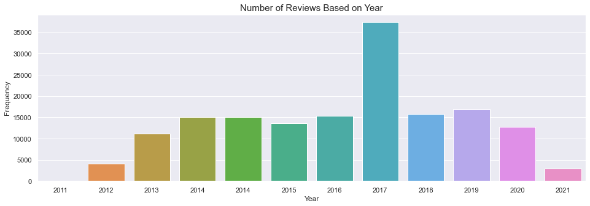

```python
make_count_plot_order(df['Year'], 'Year', 16, 5, valid_year)
```

Berdasarkan gambar di atas, terlihat bahwa tahun dengan jumlah *review* terbanyak yang diberikan pegawai terhadap perusahaannya adalah tahun 2017.

**Based on Month**

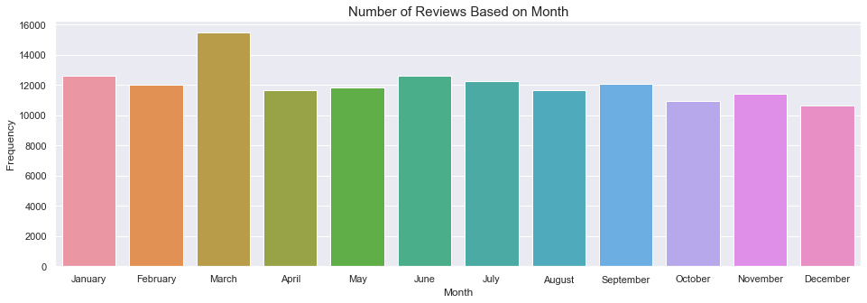

```python
make_count_plot_order(df['Month'], 'Month', 16, 5, valid_month)
```

Berdasarkan gambar di atas, terlihat bahwa bulan dengan jumlah review terbanyak yang diberikan pegawai terhadap perusahaannya adalah bulan Maret.

**Rating**

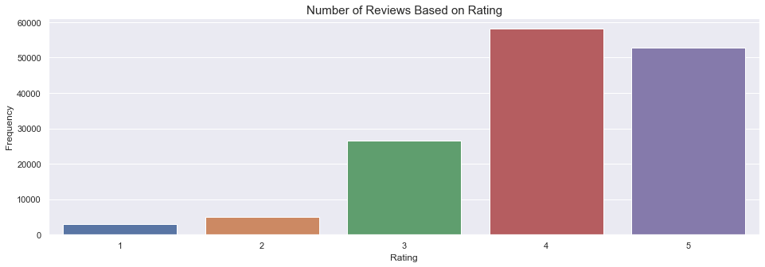

```python
make_count_plot(df['Rating'], 'Rating', 16, 5)
```

Berdasarkan *rating* yang diberikan, rating dengan jumlah *review* terbanyak adalah 4 kemudian disusul oleh 5. Hal ini menandakan bahwa rata-rata pegawai memberikan nilai *rating* yang cukup tinggi terhadap perusahannya.

**Company Name**

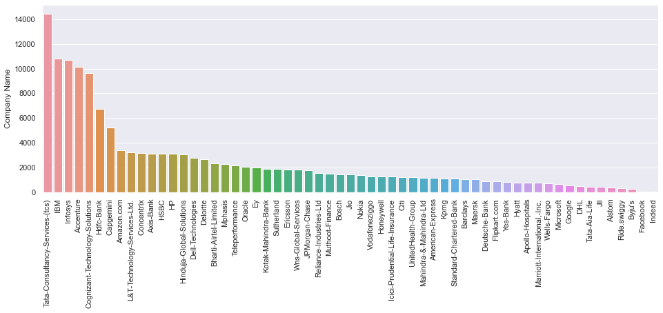

```python
plt.figure(figsize=(16,5))
df_company = df['Company Name'].value_counts()
sns.barplot(x=df_company.index,
            y=df_company)
plt.xticks(rotation=90)
plt.show()
```

Berdasarkan gambar di atas, 5 buah perusahaan dengan jumlah *review* terbanyak adalah Tata-Consultancy-Service, IBM, Infosys, Accenture, dan Cognizant Technology Solutions dengan jumlah melebihi 8000 *review*.

**Rating Based on Employee Status**

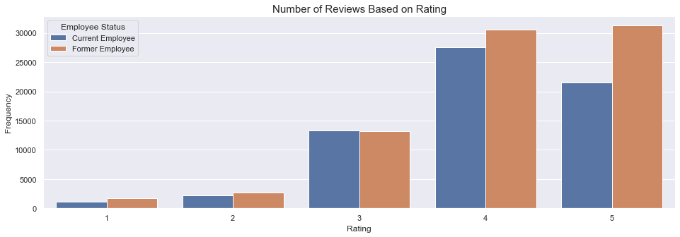

```python
make_count_plot_hue(df['Rating'], 'Rating', 16, 5, hue=df['Employee Status'])
```

Berdasarkan gambar di atas, terlihat bahwa untuk pegawai dengan status *Former Employee* memberikan nilai *rating* tinggi lebih banyak dibandingkan dengan pegawai dengan status *Current Employee*.

## Build Model

Definisikan target variabel dengan kolom `Category` yang memuat kategori dari *review* yang diberikan pegawai. Untuk *review* dengan nilai rating sebesar 1 atau 2 akan dikelompokkan ke dalam kategori *Negative*, 3 ke dalam kategori *Neutral*, 4 dan 5 ke dalam kategori *Positive*.

```python
df['Category'] = df['Rating'].replace({1:'Negative', 2:'Negative', 3:'Neutral', 4:'Positive', 5:'Positive'})
```

```python
df = df.reset_index(drop=True)
```

```python
df.head(3)
```

|  | ReviewTitle | CompleteReview | URL | Rating | ReviewDetails | Company Name | Date | Year | Month | Day | Employee Status | Category |
| --- | --- | --- | --- | --- | --- | --- | --- | --- | --- | --- | --- | --- |
| 0 | Productive | Good company, cool workplace, work load little... | https://in.indeed.com/cmp/Reliance-Industries-... | 3 | (Current Employee) - Ghansoli - August 30,... | Reliance-Industries-Ltd | 2021-08-30 | 2021 | August | 30 | Current Employee | Neutral |
| 1 | Stressful | 1. Need to work on boss's whims and fancies 2.... | https://in.indeed.com/cmp/Reliance-Industries-... | 3 | (Former Employee) - - August 26, 2021 | Reliance-Industries-Ltd | 2021-08-26 | 2021 | August | 26 | Former Employee | Neutral |
| 2 | Good Company for Every employee | Good company for every Engineers dream, Full M... | https://in.indeed.com/cmp/Reliance-Industries-... | 5 | (Former Employee) - - August 17, 2021 | Reliance-Industries-Ltd | 2021-08-17 | 2021 | August | 17 | Former Employee | Positive |

## Build Model Without Oversampling

### Number of Review

```python
df_grp_1 = df['Category'].value_counts()
df_grp_1
```

```
Positive    110796
Neutral      26465
Negative      7788
Name: Category, dtype: int64
```

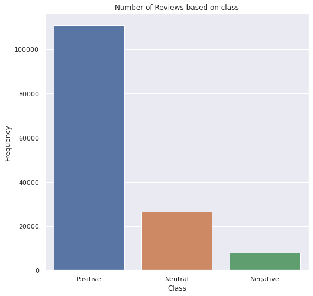

```python
plt.figure(figsize=(8,8))
sns.barplot(x=df_grp_1.index, y=df_grp_1)
plt.xlabel('Class')
plt.ylabel('Frequency')
plt.title('Number of Reviews based on class')
plt.show()
```

Berdasarkan gambar di atas, *review* dengan kategori *Positive* adalah *review* dengan jumlah terbanyak dengan total lebih dari 4x lipat dibandingkan *review* dengan kategori *Neutral*.

### Text Preprocessing

**One Hot Encoding**

Ubah kategori yang ada pada kolom `Category` menjadi numerik menggunakan `OneHotEncoder()`.

```python
ohe = OneHotEncoder(sparse=False, handle_unknown='ignore')
df_category = pd.DataFrame(ohe.fit_transform(df[['Category']]))
df_category.columns = df['Category'].sort_values().unique()
df_category = df_category.astype('int64')
df_category.head()
```

|  | Negative | Neutral | Positive |
| --- | --- | --- | --- |
| 0 | 0 | 1 | 0 |
| 1 | 0 | 1 | 0 |
| 2 | 0 | 0 | 1 |
| 3 | 0 | 0 | 1 |
| 4 | 1 | 0 | 0 |

**Create New Dataframe**

Bentuk dataframe baru yang memuat *review* yang diberikan beserta nilai kategori dari *review* tersebut.

```python
df_new = pd.concat([df['CompleteReview'], df_category], axis=1)
```

```python
df_new
```

|  | CompleteReview | Negative | Neutral | Positive |
| --- | --- | --- | --- | --- |
| 0 | Good company, cool workplace, work load little... | 0 | 1 | 0 |
| 1 | 1. Need to work on boss's whims and fancies 2.... | 0 | 1 | 0 |
| 2 | Good company for every Engineers dream, Full M... | 0 | 0 | 1 |
| 3 | I am just pass out bsc in chemistry Typical da... | 0 | 0 | 1 |
| 4 | Not so fun at work just blame games Target pe... | 1 | 0 | 0 |
| ... | ... | ... | ... | ... |
| 145044 | We get a lot to learn in the company. Very sys... | 0 | 0 | 1 |
| 145045 | Lot of scope to learn different technologies u... | 0 | 0 | 1 |
| 145046 | An overall positive experience, nice environme... | 0 | 0 | 1 |
| 145047 | Happy that I've started my career from such a ... | 0 | 1 | 0 |
| 145048 | Got good experience and knowledge about my wor... | 0 | 0 | 1 |

145049 rows × 4 columns

Saat kita melihat data pada kolom `CompleteReview`, kita melihat bahwa *review* yang diberikan oleh pegawai mengandung unsur seperti angka, tanda baca, dan banyak mengandung *stop word*. Secara umum *stop word* adalah kata umum yang biasanya muncul dalam jumlah yang besar dan dianggap tidak memiliki makna. Adapun contoh *stop word* dalam kamus Bahasa Inggris adalah "the", "a", "an", dan "in". Selain membuang angka, tanda baca, dan *stop word*, kita juga perlu melakukan *stemming* pada kalimat yang akan kita olah. *Stemming* adalah salah satu proses untuk menentukan kata dasar dari suatu kata. Misalnya terdapat kata "likes", "liked", "likely", dan "liking" yang setelah dilakukan *stemming* akan berubah menjadi kata dasarnya yaitu "like". Untuk melakukan itu semua, kita dapat menggunakan 2 buah library yaitu `Regular Expression` dan `NLTK (Natural Language Toolkit)`. Untuk melihat prosesnya, dapat dilihat pada bagian *example*.

**Example**

Pertama akan dibangun sebuah objek `example` yang menyimpan *review* pada baris kedua.

```python
example = df_new['CompleteReview'].copy()[1]
example
```

```
"1. Need to work on boss's whims and fancies 2. Priorities keep changing 3. No regards for work life balance 4. Completing the work before time is stressed too much than completing it well. Involves lots of reworking, blame games; etc. 5. No job boundaries, you will be asked to do any work depending…
```

Untuk melakukan proses *stemming* dan membuat daftar *stop word*, dapat digunakan `PorterStemmer()` untuk melakukan *stem* dan mendownload daftar *stop word* untuk Bahasa Inggris menggunakan `stopwords.words('english')`.

```python
ps = PorterStemmer()
stop_en = stopwords.words('english')
```

Untuk membuang angka dan tanda baca dapat digunakan `re.sub()` dan dilakukan proses *chaining* dengan method `lower()` untuk mengubah seluruh huruf menjadi *lower case* dan method `split()` untuk memisahkan kata.

```python
text_process = re.sub('[^a-zA-Z]', ' ', example).lower().split()
text_process[:5]
```

```
['need', 'to', 'work', 'on', 'boss']
```

Setelah itu dapat dilakukan pengecekan untuk tiap kata apakah termasuk ke dalam daftar *stop word* atau tidak.

```python
text_process = [word for word in text_process if not word in stop_en]
text_process[:5]
```

```
['need', 'work', 'boss', 'whims', 'fancies']
```

Setelah itu dapat dilakukan proses *stemming* untuk tiap kata yang ada.

```python
text_process = [ps.stem(word) for word in text_process]
text_process[:5]
```

```
['need', 'work', 'boss', 'whim', 'fanci']
```

```python
combined = ''
for text in text_process:
    combined = combined + text + ' '
combined
```

```
'need work boss whim fanci prioriti keep chang regard work life balanc complet work time stress much complet well involv lot rework blame game etc job boundari ask work depend requir '
```

Terlihat setelah dilakukan proses di atas, kalimat *review* pada baris kedua telah berubah.

**Create Function for Text Processing**

Definisikan fungsi untuk melakukan *processing* pada teks.

```python
def text_preprocessing(texts):
    text_list = []
    for i in range(len(texts)):
        text_process = re.sub('[^a-zA-Z]', ' ', texts[i]).lower().split()
        text_process = [word for word in text_process if not word in stop_en]
        text_process = [ps.stem(word) for word in text_process]
        combined = ''
        for text in text_process:
            combined = combined + text + ' '
        text_list.append(combined)
    return text_list
```

**Process Text**

```python
review = df_new['CompleteReview'].copy()
target = df_new[['Negative', 'Neutral', 'Positive']].copy()
```

```python
review = text_preprocessing(review)
```

```python
target = target.values
```

```python
review[:5]
```

```
['good compani cool workplac work load littl bit higher clean environ disciplin good cantin big campu systemat workflow lenient reliabl firm ',
 'need work boss whim fanci prioriti keep chang regard work life balanc complet work time stress much complet well involv lot rework blame game etc job boundari ask work depend requir ',
 'good compani everi engin dream full mediclaim entir famili free transport servic compani locat home township cultur employe job secur ',
 'pass bsc chemistri typic day work mangement work place good enjoy part job learn inform compani ',
 'fun work blame game target peopl less target work paid less increment make feel low much stress one understand ']
```

```python
target[:5]
```

```
array([[0, 1, 0],
       [0, 1, 0],
       [0, 0, 1],
       [0, 0, 1],
       [1, 0, 0]])
```

**Build Model**

Sebelum membangun model, akan dibagi dataset kita ke dalam *train data* dan *test data* dengan proporsi *train data* sebanyak 80% dan *test data* sebanyak 20%.

```python
X_train, X_test, y_train, y_test = train_test_split(review, target, test_size=0.2, random_state=0)
```

Setelah membagi dataset ke dalam *train data* dan *test data*, definisikan objek `tokenizer` yang akan melakukan proses *Tokenizer* atau tokenisasi. Tokenisasi adalah proses pemisahan kata dari sebuah teks untuk kemudian dianalisa lebih lanjut. Tokenisasi diperlukan untuk menghindari kompleksitas langsung dari teks asal dan sebagai salah satu cara untuk merubah *unstructured* data menjadi terstruktur. Dalam *class* `Tokenizer` akan menerima parameter `num_words` yang merupakan jumlah maksimum kata yang akan diubah menjadi token atau bilangan numerik. Selain parameter `num_words`, terdapat juga parameter `oov_token` yang akan mengganti kata-kata yang tidak dilakukan proses tokenisasi. Dalam praktiknya, tentunya akan lebih baik untuk mengganti kata yang tidak dikenakan proses tokenisasi dengan suatu kata tertentu dibandingkan melewatkannya.

Setelah dilakukan pendefinisian tokenisasi, perlu dilakukan method `.fit_on_texts()` untuk melakukan tokenisasi pada objek `tokenizer` dan teks sebagai argumennya. Selanjutnya dapat digunakan `texts_to_sequences()` untuk mengubah teks sebelumnya ke dalam bentuk *sequence*. Setelah mengubah ke dalam bentuk *sequence*, tentunya setiap baris pada teks akan mempunyai panjang yang berbeda. Dalam mengatasi hal ini, perlu dilakukan proses *padding* agar panjang setiap kalimat pada teks mempunyai panjang yang sama. Untuk melakukan *padding*, dapat digunakan `pad_sequence()`.

```python
tokenizer = Tokenizer(num_words=10000, oov_token='-')
tokenizer.fit_on_texts(X_train)
tokenizer.fit_on_texts(X_test)

sequence_train = tokenizer.texts_to_sequences(X_train)
sequence_test = tokenizer.texts_to_sequences(X_test)

pad_train = pad_sequences(sequence_train)
pad_test = pad_sequences(sequence_test)
```

**Callback Function**

Definisikan fungsi *callback* berupa `ReduceLROnPlateau()` yang akan mengurangi *learning rate* ketika metrik berhenti *improve* dan `EarlyStopping()` yang akan menghentikan proses *training* pada model saat metrik berhenti *improve*.

```python
reduce_LR = tf.keras.callbacks.ReduceLROnPlateau(
    monitor="val_loss",
    factor=0.15,
    patience=5,
    min_lr=2.e-5
)

stop_early = tf.keras.callbacks.EarlyStopping(
    monitor="val_loss",
    min_delta=0,
    patience=10,
    verbose=0,
    mode="auto",
    baseline=None,
    restore_best_weights=True
)
```

**Create Sequential Model**

Definisikan arsitektur *neural network* yang akan kita gunakan sebagai model *sequential*. Pada klasifikasi teks, hal yang paling utama adalah melakukan proses *embedding*. *Embedding* memungkinkan model memahami makna yang terkandung pada setiap kata dan akan mengelompokkan kata yang memiliki makna yang mirip. Pengelompokkan ini dilakukan dengan memetakan setiap kata ke dalam sebuah vektor dan untuk kata yang memiliki makna yang berdekatan akan memiliki nilai vektor yang mirip. Dalam `Embedding()` dapat diberikan parameter `input_dim` berupa total kata yang dilakukan proses tokenisasi dan `output_dim` berupa dimensi *embedding* yang diinginkan.

Selain melakukan proses *embedding* untuk mengelompokkan kata yang memiliki makna yang mirip, model yang ada belum bisa memahami sebuah kalimat berdasarkan kata-katanya saja. Beberapa kalimat seperti "Saya suka belajar *Machine Learning*" dan "Saya tidak suka belajar *Machine Learning*" akan mempunyai kata-kata yang mirip namun mempunyai makna yang berlawanan. Oleh karena itu, urutan dari suatu kata dapat memengaruhi makna yang ada dalam suatu kalimat. LSTM atau *Long Short Term Memory* adalah salah satu dari jenis *Recurrent Neural Network (RNN)* dan dilakukan modifikasi untuk menambahkan *memory cell* yang dapat menyimpan informasi dalam waktu yang lama. Proses ini adalah cara yang digunakan untuk mengenali makna dari suatu kalimat berdasarkan urutan kata pada kalimat kita. Penempatan *layer* LSTM dapat dilakukan setelah *layer embedding* dan sebelum *layer dense*. Pada *layer dense* kita akan menggunakan fungsi aktivasi *relu* dan pada *layer output* akan berisi 3 unit yang mewakilkan jumlah kelas pada klasifikasi teks kita berupa *Negative*, *Neutral*, dan *Positive* dengan fungsi aktivasi *softmax* yang akan mengembalikan nilai peluang dari ketiga kelas tersebut.

```python
model = tf.keras.models.Sequential([
   tf.keras.layers.Embedding(input_dim=10000, output_dim=64),
   tf.keras.layers.Dropout(0.4),
   tf.keras.layers.LSTM(64),
   tf.keras.layers.Dropout(0.3),
   tf.keras.layers.Dense(64, activation='relu'),
   tf.keras.layers.Dropout(0.2),
   tf.keras.layers.Dense(64, activation='relu'),
   tf.keras.layers.Dense(3, activation='softmax')
])
```

```python
model.summary()
```

```
Model: "sequential"
_________________________________________________________________
Layer (type)                 Output Shape              Param #
=================================================================
embedding (Embedding)        (None, None, 64)          640000
_________________________________________________________________
dropout (Dropout)            (None, None, 64)          0
_________________________________________________________________
lstm (LSTM)                  (None, 64)                33024
_________________________________________________________________
dropout_1 (Dropout)          (None, 64)                0
_________________________________________________________________
dense (Dense)                (None, 64)                4160
_________________________________________________________________
dropout_2 (Dropout)          (None, 64)                0
_________________________________________________________________
dense_1 (Dense)              (None, 64)                4160
_________________________________________________________________
dense_2 (Dense)              (None, 3)                 195
=================================================================
Total params: 681,539
Trainable params: 681,539
Non-trainable params: 0
_________________________________________________________________
```

Pada proses `.compile()`, digunakan *optimizer* berupa `Adam`, dengan *loss function* berupa *categorical_crossentropy* dikarenakan kelas yang kita miliki lebih dari dua, dan penggunaaan *metrics* berupa *accuracy* untuk melihat seberapa baik model kita melakukan klasifikasi pada teks.

```python
model.compile(
    optimizer='Adam',
    loss = 'categorical_crossentropy',
    metrics = ['accuracy']
)
```

Lakukan `.fit()` untuk melakukan proses *training* pada model. Definisikan parameter `epochs` sebanyak 30, `callback` dengan 2 fungsi *callback* yang telah didefinisikan sebelumnya.

```python
history = model.fit(
    pad_train,
    y_train,
    epochs = 30,
    callbacks = [reduce_LR, stop_early],
    validation_data = (pad_test, y_test),
    verbose = 1
)
```

Simpan model ke dalam `model.h5`.

```python
model.save('model.h5')
```

**Plot Accuracy and Loss Function**

Definisikan fungsi untuk melakukan plot *accuracy* dan *loss* dari model yang telah dilakukan proses *training*.

```python
def plot_accuracy(history):
    plt.figure(figsize=(18,5))
    acc = history.history['accuracy']
    val_acc = history.history['val_accuracy']
    epochs = range(len(acc))
    plot_acc = plt.plot(epochs, acc, 'red', label='Training Accuracy')
    plot_val_acc = plt.plot(epochs, val_acc, 'blue', label='Validation Accuracy')
    plt.xlabel('Epoch', fontsize=15)
    plt.ylabel('Accuracy', fontsize=15)
    plt.title('Training and Validation Accuracy', fontsize=25)
    plt.legend(bbox_to_anchor=(1,1), loc='best')
    plt.grid()
    plt.show()

def plot_loss(history):
    plt.figure(figsize=(18,5))
    loss = history.history['loss']
    val_loss = history.history['val_loss']
    epochs = range(len(loss))
    plot_loss = plt.plot(epochs, loss, 'red', label='Training Loss')
    plot_val_loss = plt.plot(epochs, val_loss, 'blue', label='Validation Loss')
    plt.xlabel('Epoch', fontsize=15)
    plt.ylabel('Loss', fontsize=15)
    plt.title('Training and Validation Loss', fontsize=25)
    plt.legend(bbox_to_anchor=(1,1), loc='best')
    plt.grid()
    plt.show()
```

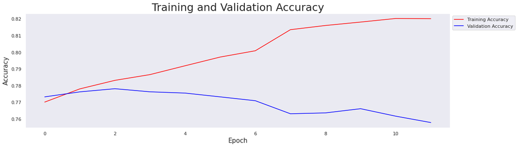

```python
plot_accuracy(history)
```

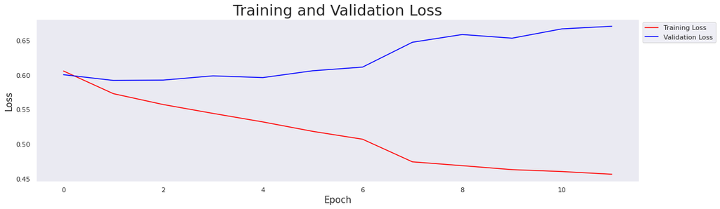

```python
plot_loss(history)
```

Melihat pada dua gambar di atas, terlihat bahwa model yang telah dibangun akan mengalami tingkat kenaikan *accuracy* pada *training data* dan mengalami penurunan *accuary* pada *testing/validation data*. Selain itu, untuk grafik *loss*, model mengalami penurunan *loss* pada *training data* dan kenaikan *loss* pada *testing/validation* data.

**Evaluate**

```python
y_pred = model.predict(pad_test)
```

```python
def make_confusion_matrix(y_pred, y_test):
    cam = confusion_matrix(np.argmax(y_test, axis=1), np.argmax(y_pred,axis=1))
    sns.heatmap(cam, annot=True, cmap='viridis',
                xticklabels=['Negative', 'Neutral', 'Positive'],
                yticklabels=['Negative', 'Neutral', 'Positive'],
                fmt="d")
    plt.xlabel('Predicted Label')
    plt.ylabel('True Label')
    plt.title('Confusion Matrix')
    plt.show()
```

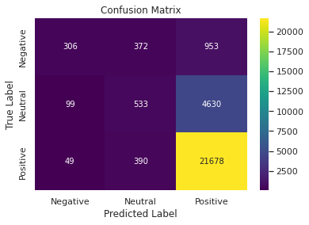

```python
make_confusion_matrix(y_pred, y_test)
```

```python
print('Accuracy Model :', accuracy_score(np.argmax(y_test, axis=1), np.argmax(y_pred,axis=1)))
```

```
Accuracy Model : 0.7761806273698725
```

Nilai *accuracy* pada model pertama sebesar 77,61%.

## **Build Model With Oversampling**

Dikarenakan sebelumnya kita melihat nilai dari tiap kelas yang kita punya tidak *balance*, akan dilakukan proses *oversampling* untuk membuat kelas pada *target* variabel kita *balance*.

```python
df_oversampling = df[['CompleteReview', 'Rating']].copy()
```

```python
df_oversampling.head()
```

|  | CompleteReview | Rating |
| --- | --- | --- |
| 0 | Good company, cool workplace, work load little... | 3 |
| 1 | 1. Need to work on boss's whims and fancies 2.... | 3 |
| 2 | Good company for every Engineers dream, Full M... | 5 |
| 3 | I am just pass out bsc in chemistry Typical da... | 5 |
| 4 | Not so fun at work just blame games Target pe... | 1 |

```python
df_oversampling['Category'] = df_oversampling['Rating'].replace({1:'Negative', 2:'Negative', 3:'Neutral', 4:'Positive', 5:'Positive'})
```

```python
df_oversampling.head()
```

|  | CompleteReview | Rating | Category |
| --- | --- | --- | --- |
| 0 | Good company, cool workplace, work load little... | 3 | Neutral |
| 1 | 1. Need to work on boss's whims and fancies 2.... | 3 | Neutral |
| 2 | Good company for every Engineers dream, Full M... | 5 | Positive |
| 3 | I am just pass out bsc in chemistry Typical da... | 5 | Positive |
| 4 | Not so fun at work just blame games Target pe... | 1 | Negative |

```python
df_oversampling['Class'] = df_oversampling['Category'].replace({'Negative':1, 'Neutral':2, 'Positive':3})
```

```python
df_oversampling.head()
```

|  | CompleteReview | Rating | Category | Class |
| --- | --- | --- | --- | --- |
| 0 | Good company, cool workplace, work load little... | 3 | Neutral | 2 |
| 1 | 1. Need to work on boss's whims and fancies 2.... | 3 | Neutral | 2 |
| 2 | Good company for every Engineers dream, Full M... | 5 | Positive | 3 |
| 3 | I am just pass out bsc in chemistry Typical da... | 5 | Positive | 3 |
| 4 | Not so fun at work just blame games Target pe... | 1 | Negative | 1 |

Definisikan `RandomOverSampler()` yang akan melakukan proses *upsampling* pada kelas dengan jumlah terkecil agar sama dengan jumlah pada kelas terbesar.

```python
ros = RandomOverSampler()

X_over, y_over = ros.fit_resample(df_oversampling[['CompleteReview']], df_oversampling['Class'])
df_x_over = pd.DataFrame(X_over)
df_y_over = pd.DataFrame(y_over)
df_new_over = pd.concat([df_x_over, df_y_over], axis=1)
df_new_over.columns = ['CompleteReview', 'Class']
```

```python
df_new_over.head()
```

|  | CompleteReview | Class |
| --- | --- | --- |
| 0 | Good company, cool workplace, work load little... | 2 |
| 1 | 1. Need to work on boss's whims and fancies 2.... | 2 |
| 2 | Good company for every Engineers dream, Full M... | 3 |
| 3 | I am just pass out bsc in chemistry Typical da... | 3 |
| 4 | Not so fun at work just blame games Target pe... | 1 |

```python
df_new_over['Category'] = df_new_over['Class'].replace({1:'Negative', 2:'Neutral', 3:'Positive'})
```

```python
df_new_over = df_new_over.reset_index(drop=True)
```

```python
df_new_over.head()
```

|  | CompleteReview | Class | Category |
| --- | --- | --- | --- |
| 0 | Good company, cool workplace, work load little... | 2 | Neutral |
| 1 | 1. Need to work on boss's whims and fancies 2.... | 2 | Neutral |
| 2 | Good company for every Engineers dream, Full M... | 3 | Positive |
| 3 | I am just pass out bsc in chemistry Typical da... | 3 | Positive |
| 4 | Not so fun at work just blame games Target pe... | 1 | Negative |

```python
df_grp_2 = df_new_over['Category'].value_counts()
df_grp_2
```

```
Positive    110796
Neutral     110796
Negative    110796
Name: Category, dtype: int64
```

**Resample Dataframe**

Dikarenakan kita ingin jumlah dataset yang digunakan sama seperti model sebelumnya, akan diambil sebagaian data saja.

```python
frac = 145049/(110796*3)
```

```python
df_over = df_new_over.sample(frac=frac, random_state=0)
```

```python
df_over = df_over.reset_index(drop=True)
df_over.head()
```

|  | CompleteReview | Class | Category |
| --- | --- | --- | --- |
| 0 | Good organisation.\r Work environment is good.... | 2 | Neutral |
| 1 | Infosys is only focused on Client requirement ... | 1 | Negative |
| 2 | I had a great time working and there was no ch... | 3 | Positive |
| 3 | I was Area manager handling 6 relationship Man... | 2 | Neutral |
| 4 | Well the feedback is based on my current proje... | 1 | Negative |

```python
df_grp_3 = df_over['Category'].value_counts()
df_grp_3
```

```
Positive    48580
Negative    48394
Neutral     48075
Name: Category, dtype: int64
```

**Number of Review**

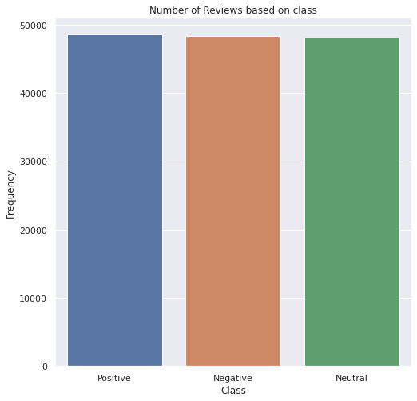

```python
plt.figure(figsize=(8,8))
sns.barplot(x=df_grp_3.index, y=df_grp_3)
plt.xlabel('Class')
plt.ylabel('Frequency')
plt.title('Number of Reviews based on class')
plt.show()
```

Terlihat pada gambar di atas, jumlah kelas pada data kita sudah sama.

**Text Processing**

```python
df_over.head()
```

|  | CompleteReview | Class | Category |
| --- | --- | --- | --- |
| 0 | Good organisation.\r Work environment is good.... | 2 | Neutral |
| 1 | Infosys is only focused on Client requirement ... | 1 | Negative |
| 2 | I had a great time working and there was no ch... | 3 | Positive |
| 3 | I was Area manager handling 6 relationship Man... | 2 | Neutral |
| 4 | Well the feedback is based on my current proje... | 1 | Negative |

**One Hot Encoding**

```python
ohe = OneHotEncoder(sparse=False, handle_unknown='ignore')
df_over_category = pd.DataFrame(ohe.fit_transform(df_over[['Category']]))
df_over_category.columns = df_over['Category'].sort_values().unique()
df_over_category = df_over_category.astype('int64')
df_over_category.head()
```

|  | Negative | Neutral | Positive |
| --- | --- | --- | --- |
| 0 | 0 | 1 | 0 |
| 1 | 1 | 0 | 0 |
| 2 | 0 | 0 | 1 |
| 3 | 0 | 1 | 0 |
| 4 | 1 | 0 | 0 |

**Create New Dataframe**

```python
df_over_new = pd.concat([df_over['CompleteReview'], df_over_category], axis=1)
```

```python
df_over_new
```

|  | CompleteReview | Negative | Neutral | Positive |
| --- | --- | --- | --- | --- |
| 0 | Good organisation.\r Work environment is good.... | 0 | 1 | 0 |
| 1 | Infosys is only focused on Client requirement ... | 1 | 0 | 0 |
| 2 | I had a great time working and there was no ch... | 0 | 0 | 1 |
| 3 | I was Area manager handling 6 relationship Man... | 0 | 1 | 0 |
| 4 | Well the feedback is based on my current proje... | 1 | 0 | 0 |
| ... | ... | ... | ... | ... |
| 145044 | Do not expect to do something new apart from v... | 1 | 0 | 0 |
| 145045 | Not recommended for others, its good for fresh... | 1 | 0 | 0 |
| 145046 | Profit oriented company not employee oriented.... | 1 | 0 | 0 |
| 145047 | Got to learn a lot of things while working wit... | 0 | 0 | 1 |
| 145048 | good working environment collegues are very co... | 1 | 0 | 0 |

145049 rows × 4 columns

**Process Text**

```python
review_over = df_over_new['CompleteReview'].copy()
target_over = df_over_new[['Negative', 'Neutral', 'Positive']].copy()
```

```python
review_over = text_preprocessing(review_over)
```

```python
target_over = target_over.values
```

```python
review_over[:5]
```

```
['good organis work environ good help peopl ',
 'infosi focus client requir fill abl focu employe concern employ unabl take earn leav ',
 'great time work challeng work repetit job day interest lack motiv factor given quarter like take outing team lunch sport cultur overal great time divis financ account ',
 'area manag handl relationship manag differ branch learn skill team leader time manag organis ',
 'well feedback base current project would vari team project work lot constraint far work life balanc concern work hour goe late night work even holiday festiv much support higher manag team also support much team uniti found ']
```

```python
target_over[:5]
```

```
array([[0, 1, 0],
       [1, 0, 0],
       [0, 0, 1],
       [0, 1, 0],
       [1, 0, 0]])
```

**Build Model**

```python
X_train_over, X_test_over, y_train_over, y_test_over = train_test_split(review_over, target_over, test_size=0.2, random_state=0)
```

```python
tokenizer_over = Tokenizer(num_words=10000, oov_token='-')
tokenizer_over.fit_on_texts(X_train_over)
tokenizer_over.fit_on_texts(X_test_over)

sequence_train_over = tokenizer.texts_to_sequences(X_train_over)
sequence_test_over = tokenizer.texts_to_sequences(X_test_over)

pad_train_over = pad_sequences(sequence_train_over)
pad_test_over = pad_sequences(sequence_test_over)
```

**Create Sequential Model**

```python
model_over = tf.keras.models.Sequential([
   tf.keras.layers.Embedding(input_dim=10000, output_dim=64),
   tf.keras.layers.Dropout(0.4),
   tf.keras.layers.LSTM(64),
   tf.keras.layers.Dropout(0.3),
   tf.keras.layers.Dense(64, activation='relu'),
   tf.keras.layers.Dropout(0.2),
   tf.keras.layers.Dense(64, activation='relu'),
   tf.keras.layers.Dense(3, activation='softmax')
])
```

```python
model_over.summary()
```

```
Model: "sequential_1"
_________________________________________________________________
Layer (type)                 Output Shape              Param #
=================================================================
embedding_1 (Embedding)      (None, None, 64)          640000
_________________________________________________________________
dropout_3 (Dropout)          (None, None, 64)          0
_________________________________________________________________
lstm_1 (LSTM)                (None, 64)                33024
_________________________________________________________________
dropout_4 (Dropout)          (None, 64)                0
_________________________________________________________________
dense_3 (Dense)              (None, 64)                4160
_________________________________________________________________
dropout_5 (Dropout)          (None, 64)                0
_________________________________________________________________
dense_4 (Dense)              (None, 64)                4160
_________________________________________________________________
dense_5 (Dense)              (None, 3)                 195
=================================================================
Total params: 681,539
Trainable params: 681,539
Non-trainable params: 0
_________________________________________________________________
```

```python
model_over.compile(
    optimizer='Adam',
    loss = 'categorical_crossentropy',
    metrics = ['accuracy']
)
```

```python
history_over = model_over.fit(
    pad_train_over,
    y_train_over,
    epochs = 30,
    callbacks = [reduce_LR, stop_early],
    validation_data = (pad_test_over, y_test_over),
    verbose = 1
)
```

Save model kedua ke dalam `model_over.h5`.

```python
model_over.save('model_over.h5')
```

**Plot**

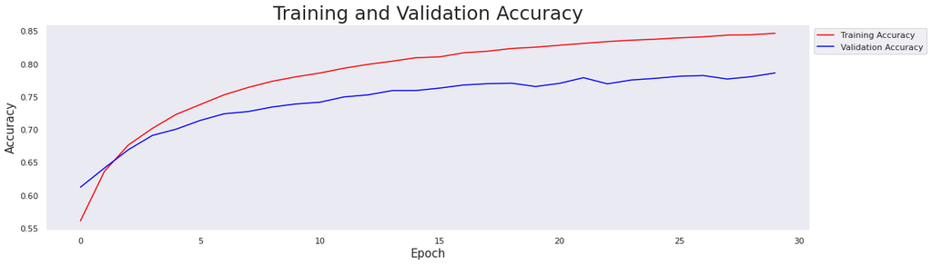

```python
plot_accuracy(history_over)
```

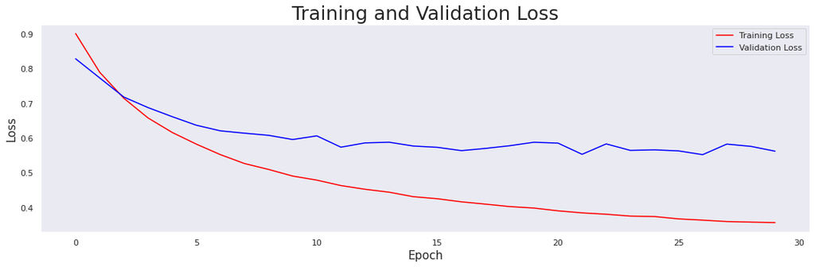

```python
plot_loss(history_over)
```

Melihat pada dua gambar di atas, terlihat bahwa model kedua yang telah dibangun setelah melakukan proses *oversampling* mengalami kenaikan nilai *accuracy* baik pada *training data* dan *testing/validation data*. Selain itu, model juga mengalmi penurunan *loss* untuk *training data* dan *testing/validation data*.

**Evaluate**

```python
y_pred_over = model_over.predict(pad_test_over)
```

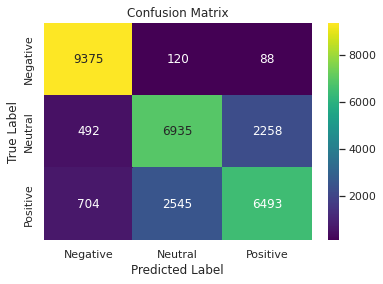

```python
make_confusion_matrix(y_pred_over, y_test_over)
```

```python
print('Accuracy Model :', accuracy_score(np.argmax(y_test_over, axis=1), np.argmax(y_pred_over,axis=1)))
```

```
Accuracy Model : 0.7860392967942089
```

Nilai *accuracy* pada model kedua adalah 78,60%.

## **Predict Text**

Setelah membangun dua buah model yang akan digunakan untuk melakukan klasifikasi pada *review* yang diberikan pegawai terhadap perusahaannya. Kita melihat bahwa pada model pertama mempunyai nilai *accuracy* sebesar 77,61% dan 78,60% untuk model kedua. Oleh karena itu, kita akan menggunakan model kedua untuk melakukan klasifikasi pada *review* selanjutnya.

**Create Function To Predict Text**

Definisikan fungsi `predict_text` untuk melakukan prediksi pada *review* yang diberikan pegawai.

```python
def predict_text(sentence, model):
    sentence = text_preprocessing(sentence)
    seq = tokenizer_over.texts_to_sequences(sentence)
    pad = pad_sequences(seq)
    pred = model_over.predict(pad)
    class_pred = np.argmax(pred, axis=1)
    labels = []
    for i in range(len(class_pred)):
        if class_pred[i] == 0:
            labels.append('Negative')
        elif class_pred[i] == 1:
            labels.append('Neutral')
        else:
            labels.append('Positive')
    return labels
```

Berikan 3 buah *review* baru untuk melihat bagaimana model yang telah dibangun dapat melakukan klasifikasi pada *review* tersebut.

```python
data = pd.DataFrame([{'Review':
                      '''
                      Excellent work-life balance with top-notch benefits.
                      The management team really seems to care about their employees.
                      You may have to work late/from home sometimes when the company needs you to,
                      but that is balanced with the ability to work from home when you need to; its a fair trade
                      '''},
                     {'Review':
                      '''
                      No work life balance whatsoever for sales Division in head office.
                      Everything have tight deadline and must be fulfilled.
                      Multi tasking here is urgently required
                      '''},
                     {'Review':
                      '''
                      Work life balance is not good in some departments.
                      Career development is not as transparent.
                      But good starting salary compared to other companies in Surabaya and the benefits is good as well.
                      '''}])
```

```python
label = predict_text(data['Review'], model_over)
```

```python
data['Category'] = label
```

```python
data
```

|  | Review | Category |
| --- | --- | --- |
| 0 | \n Excellent work-life ba... | Positive |
| 1 | \n No work life balance w... | Negative |
| 2 | \n Work life balance is n... | Neutral |

Terlihat bahwa untuk *review* pertama model mengklasifikasikan *review* tersebut ke dalam kelas *Positive*, *Negative* untuk *review* kedua, dan *Neutral* untuk *review* ketiga. Berdasarkan 3 contoh *review* yang diberikan, dapat dikatakan model dapat melakukan klasifikasi *review* dengan baik.

## **Conclusion**

Berdasarkan proses yang telah dilakukan, dapat diperoleh beberapa kesimpulan yang dapat menjawab permasalahan sebelumnya.

1. Mengetahui review yang diberikan oleh pegawai terhadap perusahaan.  
   Jawab:  
   Setelah melakukan proses *Exploratory Data Analysis*, diperoleh rata-rata *rating* yang diberikan oleh pegawai terhadap perusahaan adalah **4,053/5** yang mengindikasikan bahwa mayoritas *review* yang diberikan adalah positif. Berdasarkan jenis pegawai, *review* lebih banyak diberikan oleh *Former Employee* yaitu sebanyak **79377** *review* dibandingkan dengan *Current Employee* dengan **65672** *review*. Berdasarkan tahunnya, tahun **2017** adalah tahun dengan jumlah *review* terbanyak dibandingkan tahun lainnya. Berdasarkan bulannya, bulan *Maret* adalah bulan dengan jumlah *review* terbanyak dibandingkan bulan lainnya. 5 Perusahaan dengan jumlah *review* terbanyak adalah **Tata-Consultancy-Service**, **IBM**, **Infosys**, **Accenture**, dan **Cognizant Technology Solutions** dengan jumlah *review* untuk tiap perusahaan melebihi 8000 *review*. Dilihat berdasarkan jenis pegawai, pegawai dengan status *Former Employee* memberikan nilai *rating* tinggi lebih banyak dibandingkan dengan pegawai dengan status *Current Employee*.
1. Memprediksi *review* yang diberikan dan mengkategorikannya ke dalam review yang bersifat positif, netral, atau negatif.  
   Jawab:  
   Proses prediksi *review* yang diberikan pegawai terhadap perusahaannya dapat diprediksi menggunakan proses *Deep Learning* dengan arsitektur *Neural Network*. Proses dilakukan dengan melakukan **Tokenizer** pada teks dan dilakukan proses *padding* untuk membuat panjang tiap kalimat sama. Kemudian pembuatan arsitektur *Neural Network* dilakukan dengan menggunakan layer **Embedding** untuk mengelompokkan kata yang memiliki makna yang mirip dan diberikan *layer* **Long Short Term Memory (LSTM)** untuk mengenali makna dari suatu kalimat berdasarkan urutan kata pada kalimat. Berdasarkan arsitektur *Neural Network* ini, dibangun 2 buah model yaitu `model` untuk model tanpa proses *oversampling* pada data dan `model_over` untuk model dengan proses *oversampling* pada data. Menggunakan dua model tersebut, diperoleh nilai *accuracy* sebesar **77,61%** untuk model `model` dan **78,60%** untuk model `model_over`. Sehingga, untuk melakukan prediksi dalam klasifikasi *review* selanjutnya, dapat digunakan `model_over`.